# Bayes Statistics

2026-05-19

## Основы байесовской статистики вывода

```r
library(tidyverse)
library(arm) # for the invlogit function
library(brms)
theme_set(theme_minimal())
```

## Байесовская теорема

Байесовская теорема или Байесовское правило:

Для любых двух событий A и B

$$P(\textrm{A} | \textrm{B}) =
\frac{P(\textrm{B} | \textrm{А}) \times P(\textrm{A})}{P(\textrm{B})}$$
,

Запись статистического вывода в байесовском подходе:

$$P(θ|Data) = \frac{P(Data|θ)\times
P(θ)}{P(Data)}$$
Обычно формулу байесовского апдейта записывают проще, без знаменателя, используя символ “пропорционально”:

$$P(θ|Data) \propto P(Data|θ)\times
P(θ)$$

## Априорная вероятность, функция правдоподобия, апостериорная вероятность (постериор)

(По-английски: prior, likelihood, posterior)

- Мы заинтересованы в параметре модели **p**, описывающем наблюдаемые данные
  - в формуле выше параметр *p* - это θ
  - в сложных моделях таких *p* может быть несколько
- Мы наблюдаем данные **Data**, чтобы оценить *p*
- Как правило, *p* нам неизвестен, но у нас могут быть оценки этого параметра из опыта – априорная вероятность **P(θ)** (prior probability distribution)
- Правдоподобие – вероятность получить наблюдаемые данные при определенном значении параметра: **P(Data|θ)**
- Апостериорная вероятность – это правдоподобие значений параметра *p* после просмотра данных: **P(θ|Data)** (posterior probability distribution)  
  Постериор есть по сути комбинация прайора, данных и функции правдоподобия

Осталось определить P(Data) – это средняя вероятность, или marginal likelihood.

### Фреквентистская статистика vs байесовский вывод

Фреквентистская статистика: * только наблюдаемые данные, никаких прайоров (prior knowledge)  
* данные **случайные**  
* параметры имеют **фиксированное значение**

Байесовская статистика:  
* использует апостериорное распределение для вывода и предсказаний  
* подходит для небольших выборок и в случае, если мы имеем хорошие априорные знания о предмете  
* прайор становится постериором каждый раз, как мы видим новые данные  
* данные имеют **фиксированное значение** (после наблюдения)  
* параметры имеют **вероятностное распределение**  
* модели требуют бОльших вычислительных ресурсов, математически более сложные, с большим количеством параметров и допускают субъективный bias в моделях  
* более гибкое моделирование в случае использования марковских цепей Монте-Карло (MCMC), можно получить больше информации из моделей

## Пример: сдвиг ударения в паре глагол - существительное в английском

```r
diatones <- read.csv("https://osf.io/tqjm8/download")
summary(diatones)
```

```
##      word            syll1_coda         syll2_coda          syll2_td
##  Length:130         Length:130         Length:130         Length:130
##  Class :character   Class :character   Class :character   Class :character
##  Mode  :character   Mode  :character   Mode  :character   Mode  :character
##
##
##
##    frequency         prefix          stress_1700        stress_2005
##  Min.   :-1.386   Length:130         Length:130         Length:130
##  1st Qu.: 1.870   Class :character   Class :character   Class :character
##  Median : 3.393   Mode  :character   Mode  :character   Mode  :character
##  Mean   : 3.155
##  3rd Qu.: 4.522
##  Max.   : 6.243
##  stress_shifted
##  Min.   :0.0000
##  1st Qu.:0.0000
##  Median :0.0000
##  Mean   :0.1615
##  3rd Qu.:0.0000
##  Max.   :1.0000
```

Источник: Sonderegger, Morgan. 2023. Regression Modeling for Linguistic Data. https://osf.io/pnumg/

- 130 пар глагол-номинализация
- все пары имели одинаковое ударение на конце слова в 1700 года, как сейчас в паре *research-research*
- `stress_shifted` – бинарная переменная, указывает, изменилось ли ударение в номинализации в период с 1700 по 2005 год — например, для пары *protEst* - *prOtest* значение `stress_shifted` равно 1, для пары *debAte* - *debAte* значение 0.

Оценим количество наблюдений для каждого уровня (0 и 1):

```r
xtabs(~stress_shifted, data=diatones)
```

```
## stress_shifted
##   0   1
## 109  21
```

Data story:

0. Вначале мы ничего не знаем про вероятность сдвига ударения.
1. Истинная доля слов, в которых происходит смещение ударения, составляет p (в генеральной совокупности).
2. Каждый раз, когда мы видим новое английское слово в словарях 1700 и 2005 годов, мы получаем новое наблюдение 0 (ударение не сместилось) или 1 (ударение сместилось).
3. Каждое наблюдение (поиск пары) независимо от других.

Мы просмотрели *N* пар, из которых *k* имеют сдвиг ударения.

Запишем вероятностную модель:

- $p_{shift}$ ~ Uniform(0, 1)
- $k$ ~ Binomial ($N$, $p_{shift}$)

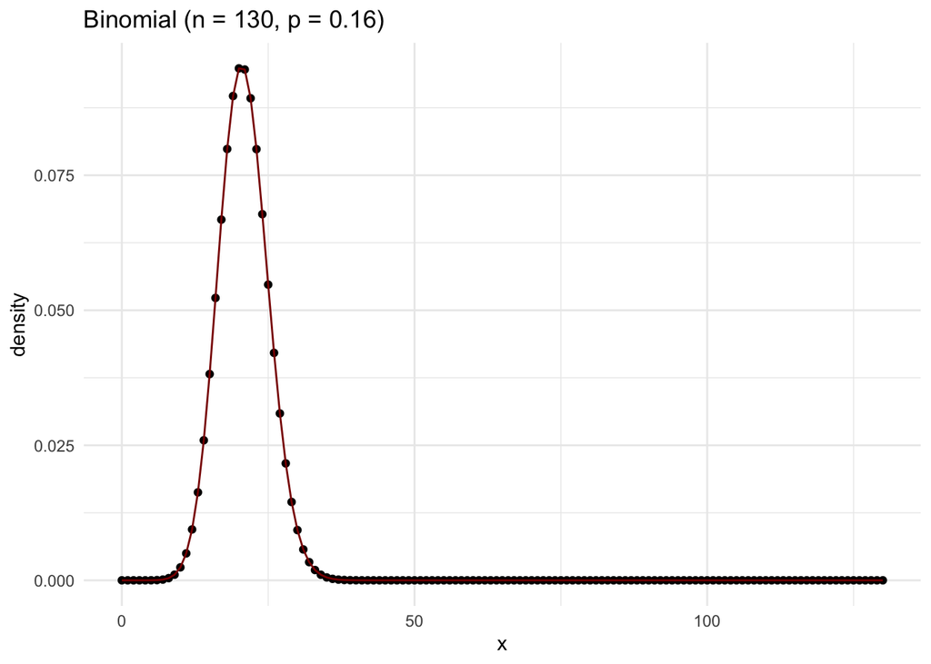

```r
tibble(x = 0:130,
           density = dbinom(x = x, size = 130, prob = 0.16)) |>
  ggplot(aes(x, density))+
  geom_point()+
  geom_line(color='darkred')+
  labs(title = "Binomial (n = 130, p = 0.16)")
```

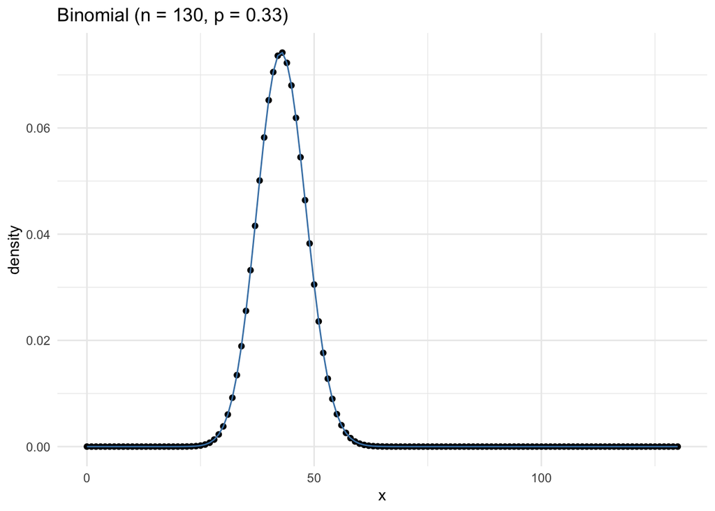

```r
tibble(x = 0:130,
           density = dbinom(x = x, size = 130, prob = 0.33)) |>
  ggplot(aes(x, density))+
  geom_point()+
  geom_line(color='steelblue')+
  labs(title = "Binomial (n = 130, p = 0.33)")
```

([Тут](https://shiny.rit.albany.edu/stat/binomial/) можно дополнительно посмотреть, как устроено биномиальное распределение для разных N и p).

Биномиальное распределение сопряжено с семейством распределений, называемым бета-распределение, которое задается параметрами α и β. Вот пугающие формулы:

$$P(x; α, β) = \frac{x^{α-1}\times
(1-x)^{β-1}}{B(α, β)}; 0 \leq x \leq 1; α, β > 0$$

Бета-функция:

$$\textrm{Βeta}(α, β) = \frac{Γ(α)\times
Γ(β)}{Γ(α+β)} = \frac{(α-1)!(β-1)!}{(α+β-1)!}$$

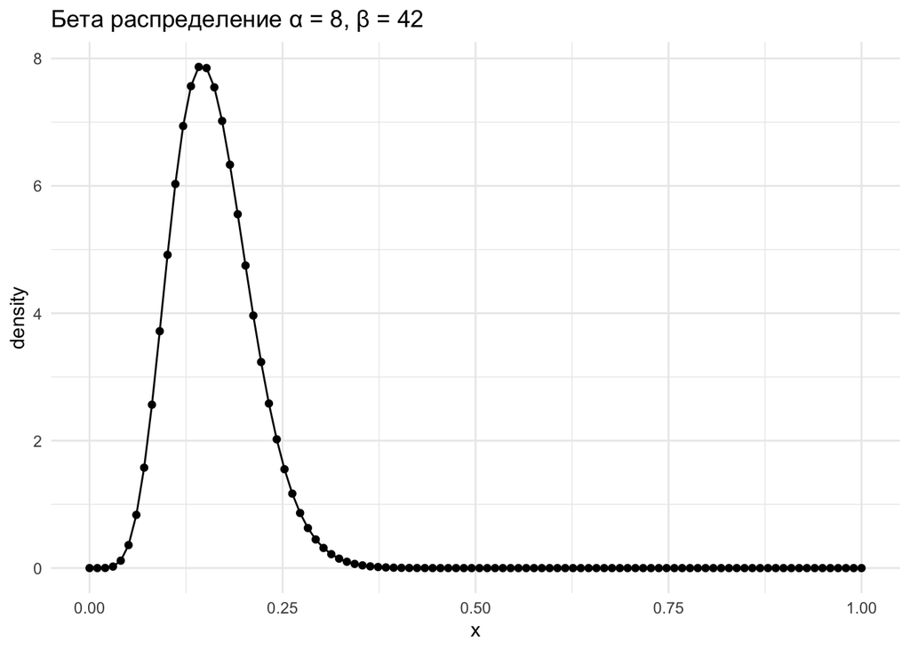

```r
tibble(x = seq(0, 1, length.out = 100),
           density = dbeta(x = x, shape1 = 8, shape2 = 42)) |>
  ggplot(aes(x, density))+
  geom_point()+
  geom_line()+
  labs(title = "Бета распределение α = 8, β = 42")
```

Можно поиграть с разными параметрами:

```r
shiny::runGitHub("agricolamz/beta_distribution_shiny")
```

Среднее и дисперсия:

$$\mu =
\frac{\alpha}{\alpha+\beta}$$

$$\sigma^2 =
\frac{\alpha\times\beta}{(\alpha+\beta)^2\times(\alpha+\beta+1)}$$

## Байесовский апдейт:

- Постепенный процесс — обновление постериора. Когда мы видим данные $y_{1+1}$, пора обновить прайор на основе $y_1$
- Или можем обновить постериор один раз, увидев все N точек наблюдения вместе

$$\textrm{Beta}_{post}(\alpha_{post},
\beta_{post}) = \textrm{Beta}(\alpha_{prior}+\alpha_{data},
\beta_{prior}+\beta_{data}),$$
где $Beta$ — это бета распределение.

Подставим формулу для биномиальной функции правдоподобия в правило Байеса, чтобы получить математическую формулу для апостериорного распределения:

$$P(p | D) = \frac{P(D | p) \times
P(p)}{P(D)}$$
,

$$P(p | k) = \frac{ \binom{n}{k}p^k(1 -
p)^{n-k} }{P(k)} \textrm{ for } 0 \leq p \leq 1$$
(здесь прайор плоский, принадлежащий равномерному (uniform) распределению: он равен 1 если $0 \leq p \leq 1$) или 0 в противном случае).

Или проще, без знаменателя:

$$P(p | k) \propto \binom{n}{k}p^k(1 -
p)^{n-k} \textrm{ for } 0 \leq p \leq 1$$
## Прайор, постериор и размер выборки

Давайте построим график априорного и апостериорного распределения, предполагая, что мы только что видели данные из нашего датасета по сдвигу ударения для:

- 5 наблюдений
- 10 наблюдений
- 65 наблюдений (50% данных)
- 130 наблюдений (все данные)

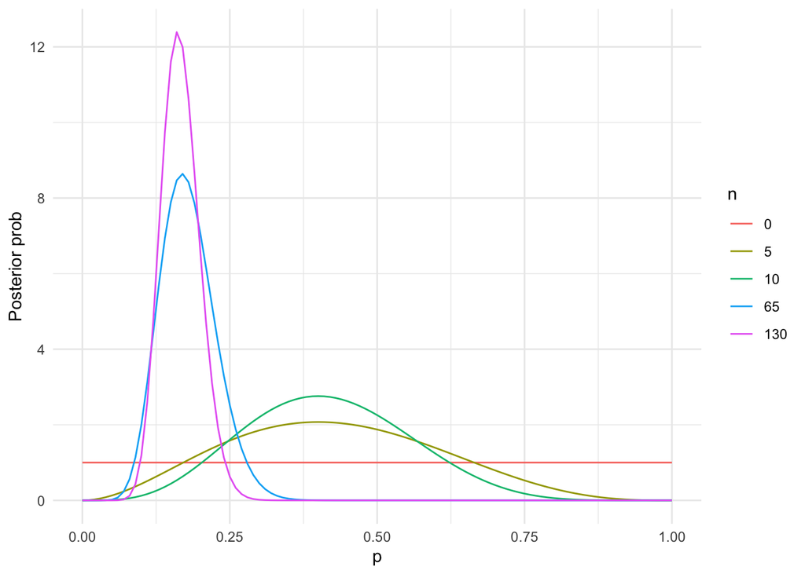

```r
# Beta is conjugate prior for binomial means:
# If you start with a Beta(\alpha, \beta) prior,
# then observe $k$ $y=1$ observations of $N$ total, the posterior is:
# Beta(k+\alpha, N-k + \beta)

# For this case:

#The numbers of observations with `stress_shifted`=1 in the first 5/10/65/130 observations are:
k_5 <- sum(diatones$stress_shifted[1:5])
k_10 <- sum(diatones$stress_shifted[1:10])
k_65 <- sum(diatones$stress_shifted[1:65])
k_130 <- sum(diatones$stress_shifted[1:130])

#set up a vector of p=0...1
p_vec <- seq(0,1, by=0.01)

# beta dist parameters for the prior
a <- 1
b <- 1

## you can also use a map function here
bind_rows(
  data.frame(p=p_vec, post=dbeta(p_vec, a,b), n=0),
  data.frame(p=p_vec, post=dbeta(p_vec, a+k_5,b+5-k_5), n=5),
  data.frame(p=p_vec, post=dbeta(p_vec, a+k_10,b+10-k_10), n=10),
  data.frame(p=p_vec, post=dbeta(p_vec, a+k_65,b+65-k_65), n=65),
    data.frame(p=p_vec, post=dbeta(p_vec, a+k_130,b+130-k_130), n=130)

) %>% mutate(n=factor(n)) %>% ## make the plot
  ggplot(aes(x=p, y=post)) + geom_line(aes(color=n)) +
  ylab("Posterior prob")
```

Для построения этого графика нам не нужно компьютерной симуляции, потому что бета-распределение - это сопряженный прайор для биномиального распределения, то есть, постериор тоже подчиняется бета-распределению.

Обратите внимание, как сильно смещается апостериорное распределение в первых 10 наблюдениях по сравнению с последними 50% наблюдений.

Этот пример демонстрирует, что:

- Апостериорное распределение представляет собой компромисс между априорным распределением и функцией правдоподобия.
- Для небольших выборок априорное распределение имеет большее значение.
- Для достаточно больших выборок функция правдоподобия доминирует.

## Упражнение:

Постройте аналогичный график для другого значения прайора, помня, что его значения редко попадают в первые и последние 5%. Вам нужно изменить `a` и `b` в коде.

Сравните распределения на двух графиках (i) для малых выборок (N=5, N=10) и больших выборок (N=65, N=130)?

## Оценка постериора

- мы можем оценить параметр модели θ:
  - среднее апостериорного распределения (mean of the posterior estimation)
  - медиану апостериорного распределения (median of the posterior estimation)
  - точку максимума апостериорного распределения (maximum a posteriori estimation, MAP), т. е. точку максимума плотности, в которой кривая достигает пика
  - байесовский доверительный интервал
- ответить на вопросы вроде:
  - какова вероятность, что значение θ больше некоторого значения $x$?
  - какова вероятность, что значение θ лежит в интервале $[x; y]$?
- построить выборки из апостериорного распределения (Posterior simulation):
  - симулировать большую выборку из апостериорного распределения;
  - использовать полученную выборку для статистического вывода.

## Вычисление постериора

Для вычисления апостериорного распределения используется ряд методов, например, Grid approximation и Quadratic approximation (частный случай maximum a-posteriori estimate, MAP-estimate). Еще один широко используемый метод - MCMC (Markov Chain Monte Carlo).

Основная идея MCMC заключается в том, что зачастую гораздо проще моделировать на основе апостериорного распределения, чем фактически его вычислять. Алгоритмы MCMC «обходят» апостериорное распределение стохастическим образом, строя выборку параметров (в нашем случае, p) на каждом шаге. «Обход» определяется таким образом, что выборка аппроксимирует апостериорное распределение — после достаточно долгого ожидания.

Самый простой алгоритм MCMC называется алгоритмом Метрополиса-Гастингса. MCMC «легче увидеть, чем понять» (МакЭлрит). Откройте [демо](https://chi-feng.github.io/mcmc-demo/), затем:  
* Нажмите Random Walk Metropolis Hastings * Установите «целевое распределение» на «стандартное» (target distribution >> standard).

В основе распределения лежит двумерное (2D) гауссово распределение — гауссов холм. (В одном измерении, на срезе — это гауссово распределение.) Обратите внимание, как маргинальные распределения (по осям) приближаются к нормальным распределениям по мере увеличения времени работы симуляции.

Еще одна визуализация от Г. Мороза:

```r
library(ggtext)
shiny::runGitHub("agricolamz/mcmc_shiny")
```